# # IL Financial Contributions to 2016 Presidential Campaigns

## Abstract

This is an exploration data analysis on IL 2016 US presidential campaign contribution.

The dataset can be found [here](http://classic.fec.gov/disclosurep/PDownload.do)

Here is the list of variables contained in this file:

- cmte_id
- cand_id
- cand_nm
- contbr_nm
- contbr_city
- contbr_st
- contbr_zip
- contbr_employer
- contbr_occupation
- contb_receipt_amt
- contb_receipt_dt
- receipt_desc"
- memo_cd
- memo_text
- form_tp
- file_num
- tran_id
- election_tp

When I first get this dataset, and scan through it. Here are some questions I  
immediately have. I will try to answer these questions during the exploration.  
I will see if there are additional questions I can answer when I play around  
with the data.

- Which candidate receives the most money?
- Which candidate has the most supporters?
- Who donates the highest amount of money?
- What do the donors do?
- How do these donors donate?

## Initial Data Exploration

```
## [1] 250411     18
```

[output not shown]

[output cut: 11 more lines]

[output not shown]

```
##  [1] "cmte_id"           "cand_id"           "cand_nm"
##  [4] "contbr_nm"         "contbr_city"       "contbr_st"
##  [7] "contbr_zip"        "contbr_employer"   "contbr_occupation"
## [10] "contb_receipt_amt" "contb_receipt_dt"  "receipt_desc"
## [13] "memo_cd"           "memo_text"         "form_tp"
## [16] "file_num"          "tran_id"           "election_tp"
```

This is a big dataset, with 250k rows of data, and 18 variables.

## Univariate Plots Section

### Contribution Amount Info

Let’s take a quick look at the summary of this information.

```
##     Min.  1st Qu.   Median     Mean  3rd Qu.     Max.
## -10000.0     15.0     27.0    113.1     80.0  10800.0
```

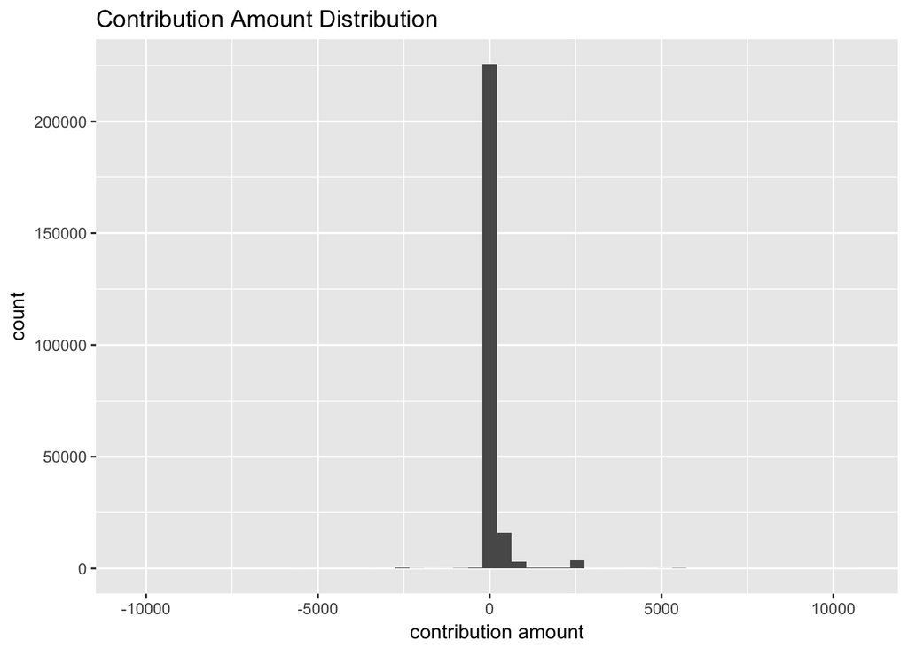

As you can seen in the plots and summary,there are a lot of outliers in this  
dataset. Most donation are grouped together with several outliers.  
Unexpectedly, there are some negative donations as well. Details cannot be  
shown clearly in the orginal plots without transformation. Therefore, I am  
going to add some transformation to this plot.

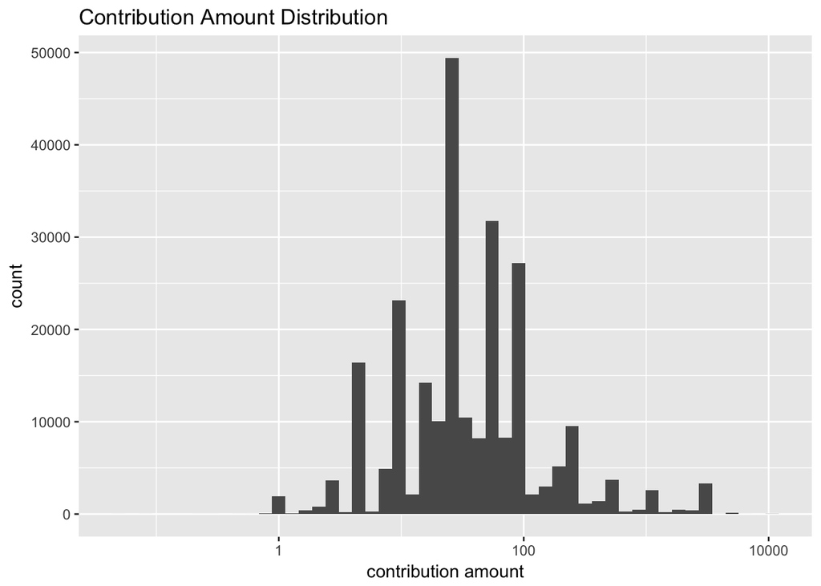

We can see the trends of this dataset more clearly right now. However, there  
is a potential issue. Since the dataset contains several negative  
contributions, which doesnt’ work well with log10. In my analysis, I will omit  
these negative amount since they are refund when the contribution exceeds the [limits](https://www.fec.gov/help-candidates-and-committees/candidate-taking-receipts/contribution-limits-candidates/). They are not very helpful for my analysis.  
Based on the warning messages, around 3k rows are removed, which is around 1%  
of the total dataset.

Since I am more interested in the contribution between 0 to 2700. I will remove them from the dataframe.

```
##    cmte_id            cand_id            cand_nm
##  Length:247227      Length:247227      Length:247227
##  Class :character   Class :character   Class :character
##  Mode  :character   Mode  :character   Mode  :character
##
##
##
##
##   contbr_nm         contbr_city         contbr_st
##  Length:247227      Length:247227      Length:247227
##  Class :character   Class :character   Class :character
##  Mode  :character   Mode  :character   Mode  :character
##
##
##
##
##    contbr_zip        contbr_employer    contbr_occupation
##  Min.   :        0   Length:247227      Length:247227
##  1st Qu.:600932103   Class :character   Class :character
##  Median :605545000   Mode  :character   Mode  :character
##  Mean   :537611329
##  3rd Qu.:606474216
##  Max.   :629953719
##  NA's   :5
##  contb_receipt_amt contb_receipt_dt   receipt_desc
##  Min.   :   0.05   Length:247227      Length:247227
##  1st Qu.:  15.00   Class :character   Class :character
##  Median :  27.00   Mode  :character   Mode  :character
##  Mean   : 116.73
##  3rd Qu.:  80.00
##  Max.   :2700.00
##
##    memo_cd           memo_text           form_tp
##  Length:247227      Length:247227      Length:247227
##  Class :character   Class :character   Class :character
##  Mode  :character   Mode  :character   Mode  :character
##
##
##
##
##     file_num         tran_id          election_tp
##  Min.   :1003942   Length:247227      Length:247227
##  1st Qu.:1077916   Class :character   Class :character
##  Median :1096260   Mode  :character   Mode  :character
##  Mean   :1101808
##  3rd Qu.:1133832
##  Max.   :1146165
##
```

Let’s see the distribution right now.

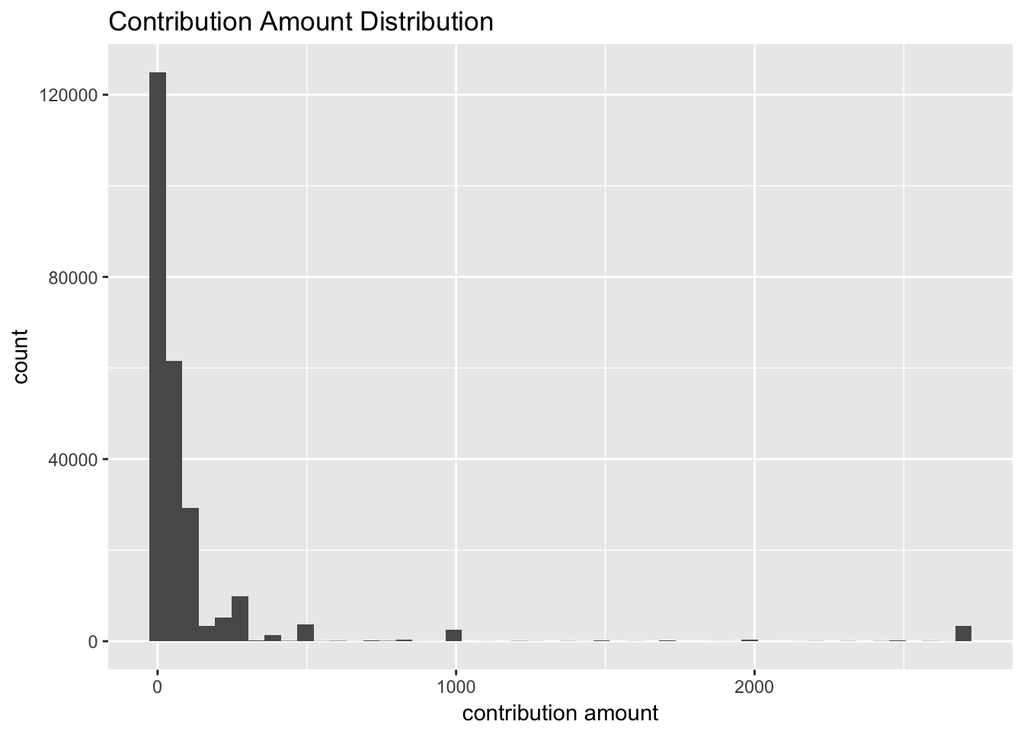

It is very clear that there are several outliers, which is higher than $500.  
Let’s do the transformation.

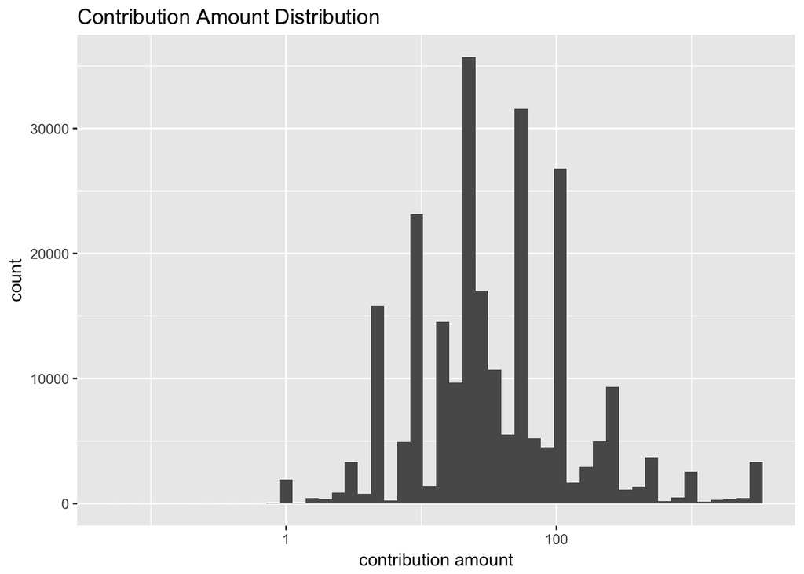

### Candidate Info

```
##
##                 Bush, Jeb       Carson, Benjamin S.
##                       571                      5889
##  Christie, Christopher J.   Clinton, Hillary Rodham
##                       119                    121482
## Cruz, Rafael Edward 'Ted'            Fiorina, Carly
##                     13024                       664
##        Graham, Lindsey O.            Huckabee, Mike
##                        80                       159
##             Jindal, Bobby             Johnson, Gary
##                         3                       444
##           Kasich, John R.          Lessig, Lawrence
##                      1026                        65
##            McMullin, Evan   O'Malley, Martin Joseph
##                        34                       163
##         Pataki, George E.                Paul, Rand
##                         6                      1163
##    Perry, James R. (Rick)              Rubio, Marco
##                         2                      2731
##          Sanders, Bernard      Santorum, Richard J.
##                     76009                        27
##               Stein, Jill          Trump, Donald J.
##                       406                     22746
##             Walker, Scott     Webb, James Henry Jr.
##                       404                        10
```

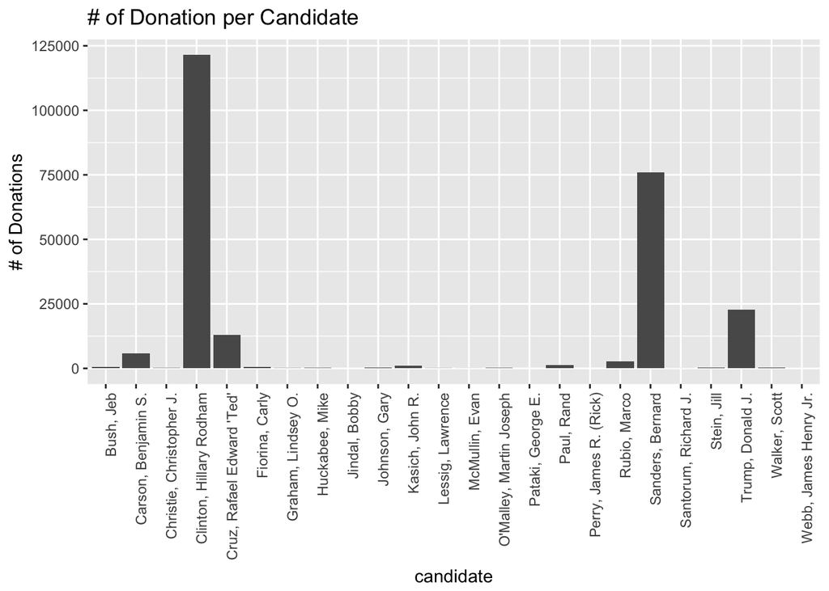

### Contributor Occupation

The contributor’s occupation information is not clean. Based on a quick summary of this part of data, the name of occupation is not consistent. There are a lot of occupation with only 1 contributor. Therefore, to better understand it, I will only focus on the top 10 occupations.

```
##  [1] "RETIRED"      "NOT EMPLOYED" "ATTORNEY"     "TEACHER"
##  [5] "PROFESSOR"    "PHYSICIAN"    "HOMEMAKER"    "CONSULTANT"
##  [9] "SALES"        "LAWYER"
```

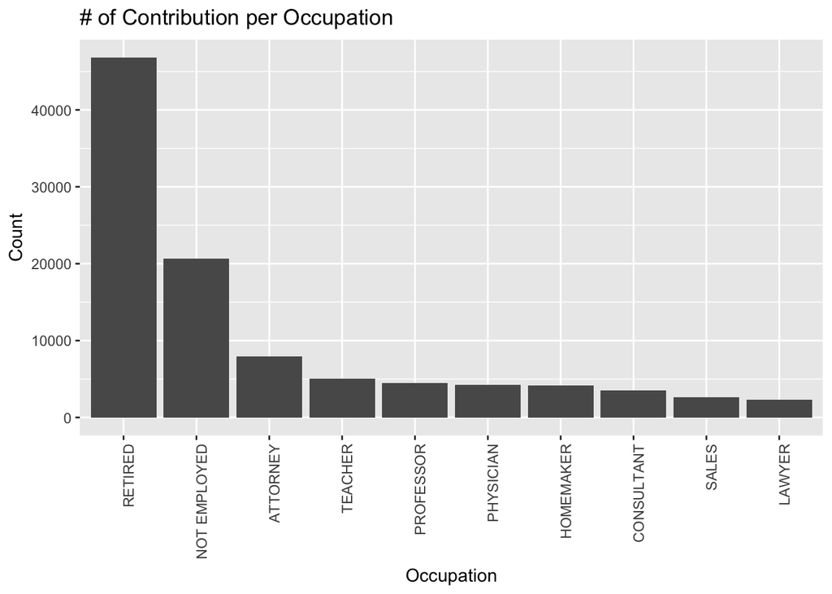

Based on a quick summary for the contribution information, we can see that retired people are more involved in the presidential campaign, following by non-employed people.

### Contribution Date

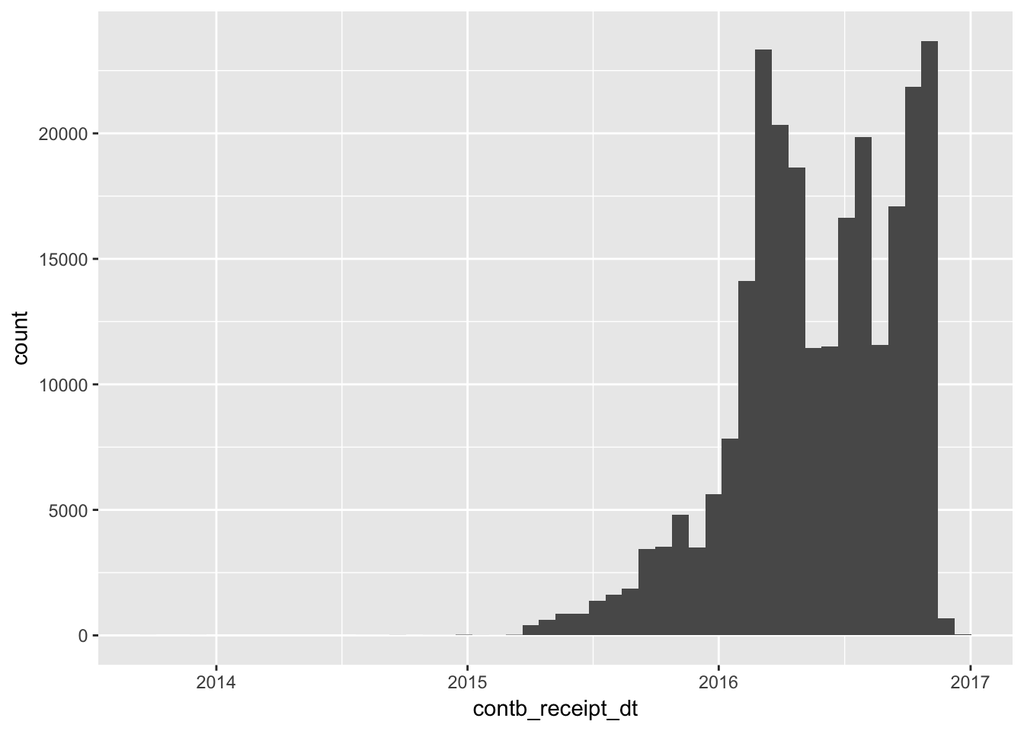

### Party

The dataset doesn’t have the party information of all the candidates. I will create the party variable based on my understanding of each candidate.

```
##  [1] "Rubio, Marco"              "Paul, Rand"
##  [3] "Webb, James Henry Jr."     "Cruz, Rafael Edward 'Ted'"
##  [5] "Graham, Lindsey O."        "Carson, Benjamin S."
##  [7] "Clinton, Hillary Rodham"   "Fiorina, Carly"
##  [9] "Sanders, Bernard"          "O'Malley, Martin Joseph"
## [11] "Huckabee, Mike"            "Santorum, Richard J."
## [13] "Pataki, George E."         "Perry, James R. (Rick)"
## [15] "Stein, Jill"               "Bush, Jeb"
## [17] "Walker, Scott"             "Trump, Donald J."
## [19] "Christie, Christopher J."  "Kasich, John R."
## [21] "Lessig, Lawrence"          "Jindal, Bobby"
## [23] "Johnson, Gary"             "McMullin, Evan"
```

```
## # A tibble: 3 x 5
##        party  sum_party number_of_candidate mean_party      n
##        <chr>      <dbl>               <int>      <dbl>  <int>
## 1   democrat 19818978.8                   4 4954744.71 197566
## 2     others   216398.8                   3   72132.95    884
## 3 republican  8823976.3                  17  519057.43  48777
```

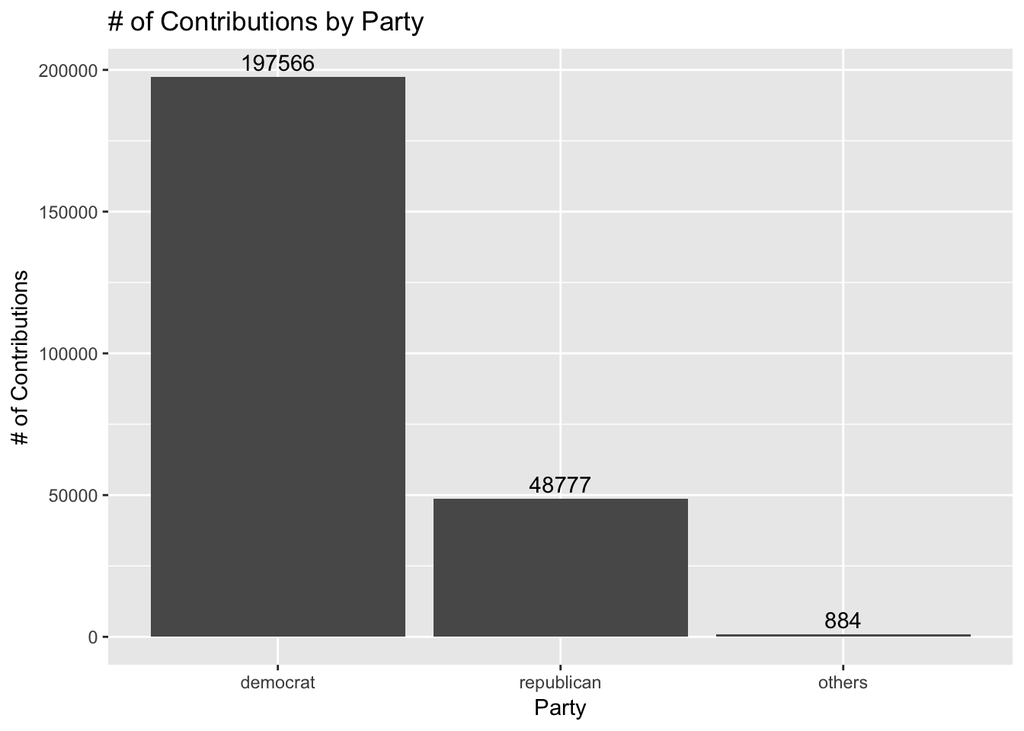

### Contribution City

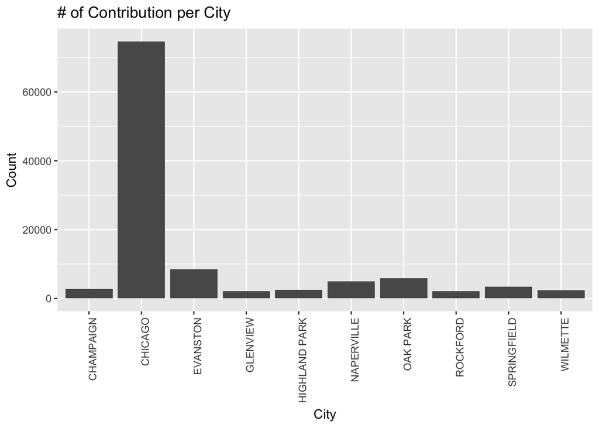

People in Chicago are much more involved in the contribution campaign than  
any other cities in Illinois.

## Univariate Analysis

### What is the structure of your dataset?

This dataset has 250,411 observations, and 18 variables (features). The detail list of the all the variables can be found in the Abstract section. The features I am most interested in this datasets are the candidates and the amount they received.

### What is/are the main feature(s) of interest in your dataset?

I am mainly interested in the contribution amount, who is contributing and how much each candidate received. I will try to answer the questions in the abstract section.

### What other features in the dataset do you think will help support your investigation into your feature(s) of interest?

The occupation is the feature that can help support my investigation. As the plots showing above, the average of contribution amount varies a lot among different occupations.

### Did you create any new variables from existing variables in the dataset?

There is only candidate name and id information instead of party information, which is an important factor when analyzing presidential campaign. Therefore, I created a “party” variable using the candidate name.

### Of the features you investigated, were there any unusual distributions? Did you perform any operations on the data to tidy, adjust, or change the form of the data? If so, why did you do this?

As mentioned above, I omitted the negative contribution, which is the refund amount that exceeds the $2,700 limitation.

## Bivariate Plots Section

### Occupation & Contribution Amount

```
## # A tibble: 10 x 4
##    contbr_occupation sum_occupation mean_occupation     n
##                <ord>          <dbl>           <dbl> <int>
##  1      NOT EMPLOYED      1019890.7        49.37742 20655
##  2           TEACHER       291138.5        58.08828  5012
##  3             SALES       240774.8        90.31311  2666
##  4         PROFESSOR       415041.4        92.78816  4473
##  5           RETIRED      4600109.8        98.23837 46826
##  6        CONSULTANT       503654.2       143.81900  3502
##  7         PHYSICIAN       691587.9       163.34150  4234
##  8         HOMEMAKER      1031595.0       248.15853  4157
##  9            LAWYER       596629.7       259.06628  2303
## 10          ATTORNEY      2584021.5       324.01524  7975
```

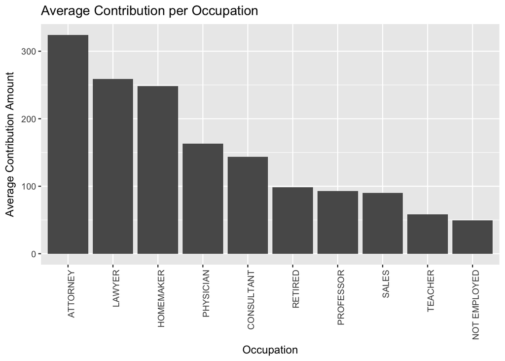

As discussed above, retired and non-employed people are more involved in the presidential campaign. However, from an average contribution perspective, attorney has the highest average contribution, following by lawyer and homemaker, whose average contribution is almost the same. Non-employed people have the lowest average contribution.

```
## # A tibble: 10 x 4
##    contbr_occupation sum_occupation mean_occupation     n
##                <ord>          <dbl>           <dbl> <int>
##  1           RETIRED      4600109.8        98.23837 46826
##  2          ATTORNEY      2584021.5       324.01524  7975
##  3         HOMEMAKER      1031595.0       248.15853  4157
##  4      NOT EMPLOYED      1019890.7        49.37742 20655
##  5         PHYSICIAN       691587.9       163.34150  4234
##  6            LAWYER       596629.7       259.06628  2303
##  7        CONSULTANT       503654.2       143.81900  3502
##  8         PROFESSOR       415041.4        92.78816  4473
##  9           TEACHER       291138.5        58.08828  5012
## 10             SALES       240774.8        90.31311  2666
```

[figure not shown]

### Party & Contribution Amount

We have seen the # of contribution per party in the previous exploration. Let’s take a look at the contribution amount per party right now.

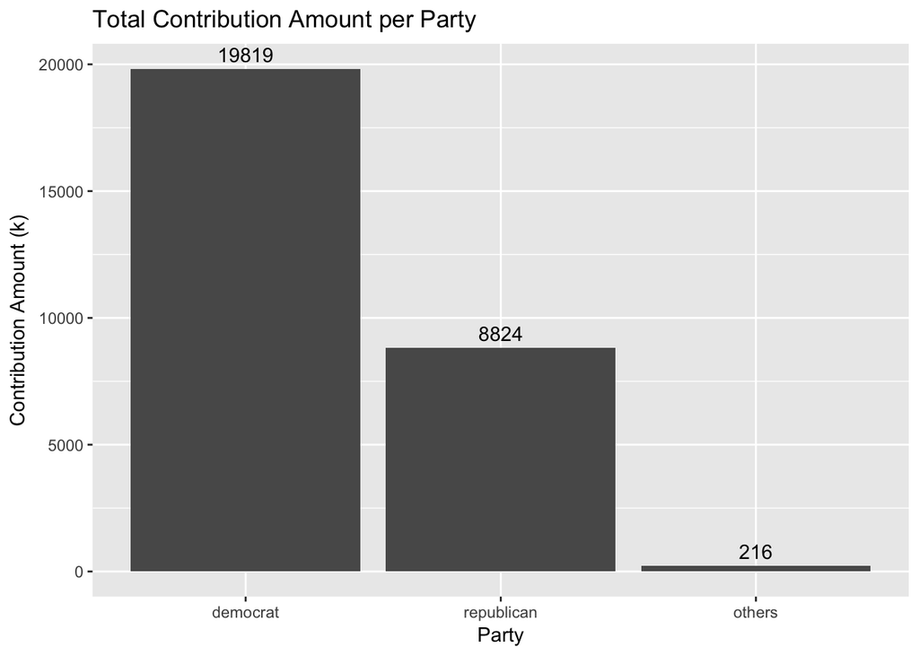

```
## [1] 0.6867437
```

There is no surprise here. Democracy still receives twice as much as republican received. Other parties receive very small amounts. Domocracy recevied almost  
70% of the total contribution.

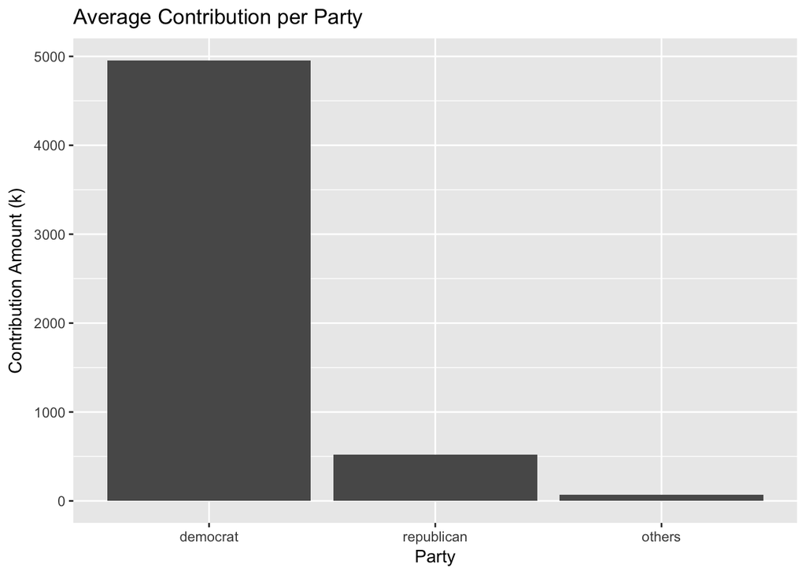

```
## [1] 9.545658
```

There are even more differences here. Democracy received more than 9 times of the contribution as much as republican received.

### Candidate & Contribution Amount

```
## cand_nm
##    Perry, James R. (Rick)         Pataki, George E.
##                   1000.00                   4200.00
##             Jindal, Bobby            McMullin, Evan
##                   5500.00                   6262.71
##     Webb, James Henry Jr.      Santorum, Richard J.
##                   8150.00                  11322.46
##            Huckabee, Mike          Lessig, Lawrence
##                  15800.20                  21393.89
##        Graham, Lindsey O.               Stein, Jill
##                  78210.00                 103448.98
##             Johnson, Gary   O'Malley, Martin Joseph
##                 106687.15                 127415.00
##            Fiorina, Carly  Christie, Christopher J.
##                 145737.50                 157173.00
##                Paul, Rand             Walker, Scott
##                 207663.76                 328176.00
##           Kasich, John R.                 Bush, Jeb
##                 580348.25                 595465.00
##       Carson, Benjamin S.              Rubio, Marco
##                 674345.63                1083018.14
## Cruz, Rafael Edward 'Ted'          Sanders, Bernard
##                1229152.28                3426060.09
##          Trump, Donald J.   Clinton, Hillary Rodham
##                3579449.08               16363374.86
```

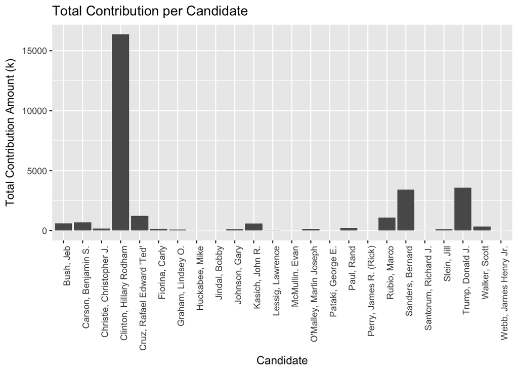

```
## [1] 0.5670042
```

### Contribution & City

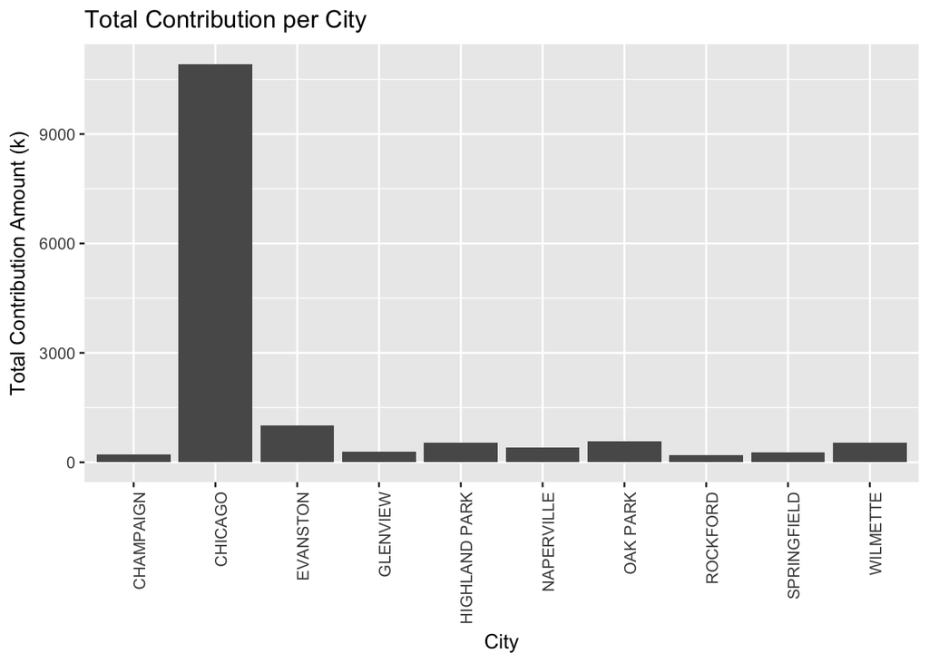

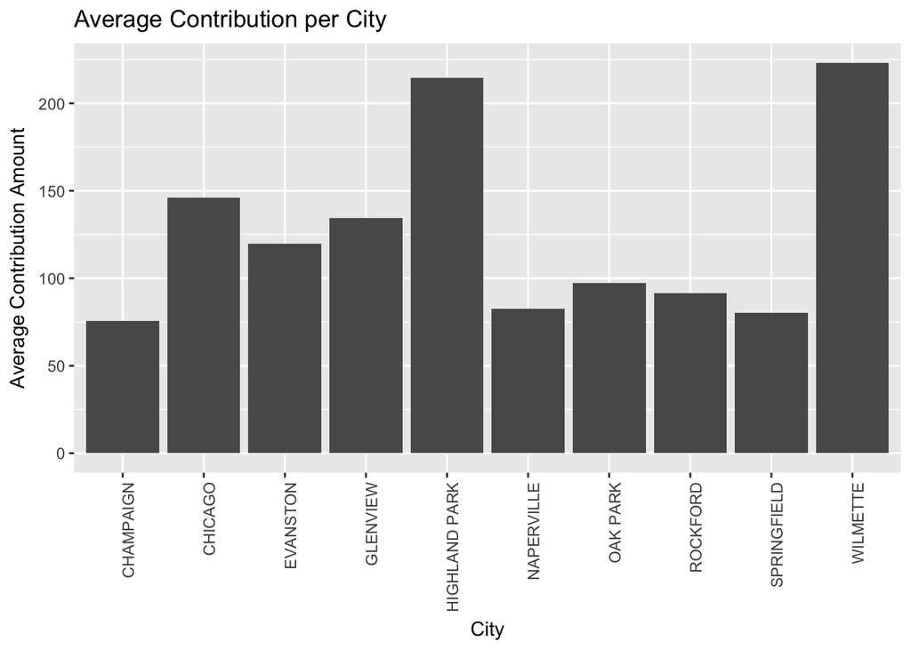

## Bivariate Analysis

### Did you observe any interesting relationships between the other features (not the main feature(s) of interest)?

Homemakers have the average contribution almost the same with lawyers. They  
have the 3rd highest average contribution in Illinois.

I did really know there is a big difference between attorney and lawyer.  
However, just from the contribution perspective, attorneys are more involved,  
and contribute more than lawyers.

### What was the strongest relationship you found?

In Illinois, people support Democracy more, especially Hillary Cliton.

## Multivariate Plots Section

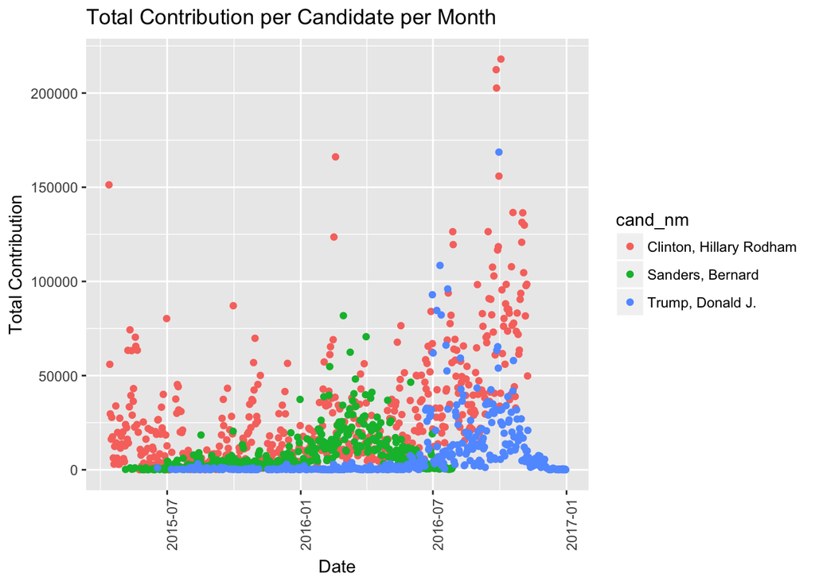

We can see, from this plot, that Hiliary Clinton leads the total contribution  
amount. Bernard Sanders has more contribution from 2015 to 2016. Donald Trump  
has few contributions at the beginning, but starts to get more since 2016.

# Multivariate Analysis

### Talk about some of the relationships you observed in this part of the investigation. Were there features that strengthened each other in terms of looking at your feature(s) of interest?

- Hiliary Clinton leads the total contribution amount all the time. She  
  received more contributions towards the end of the campaign.
- Bernard Sanders has more contribution from 2015 to 2016, but almost none at  
  the end of the campaign.
- Donald Trump has few contributions at the beginning, but starts to get more  
  since 2016.

### Were there any interesting or surprising interactions between features?

For a very short period of time, Bernard Sanders received more contributions  
than Hillary Clinton.

## Final Plots and Summary

### Plot One: Most people contribution $100 or less

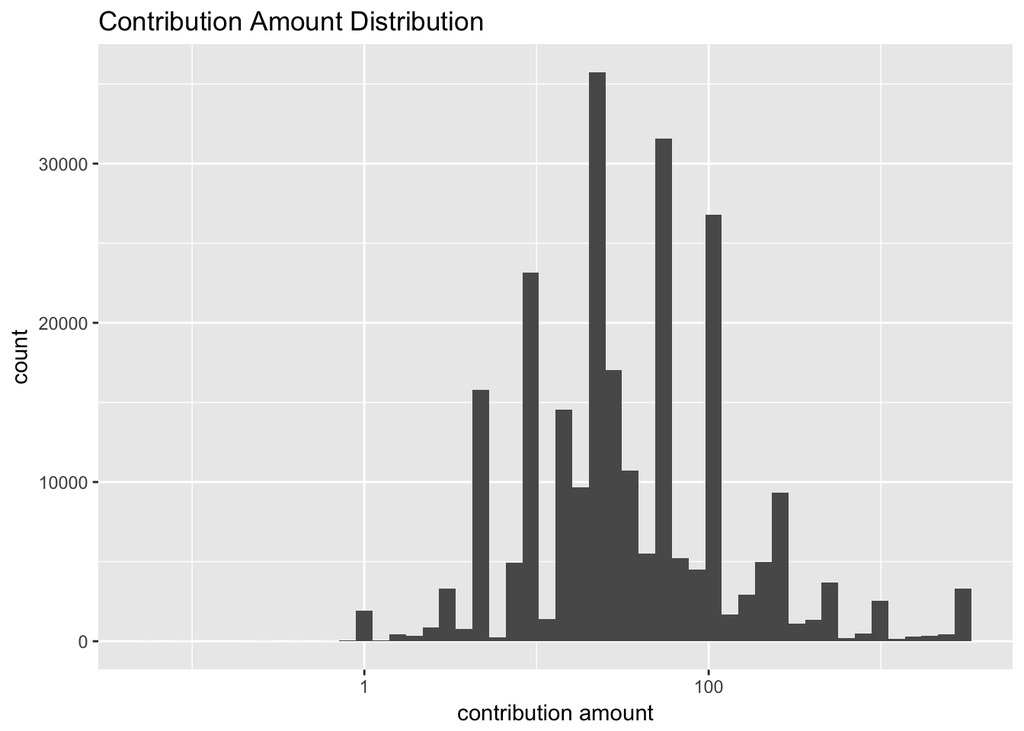

### Description One

I am not very familiar with the presidential campaign. When I first saw the  
dataset, I thought I could find people who was very crazy and would donate  
thousands of dollars. To my surprise, most people donate $100 or less. Later,  
I noticed that there are acutally $2,700 contribution limitation.

### Plot Two: Attorney has the highest average contribution

```
## # A tibble: 10 x 4
##    contbr_occupation sum_occupation mean_occupation     n
##                <ord>          <dbl>           <dbl> <int>
##  1      NOT EMPLOYED      1019890.7        49.37742 20655
##  2           TEACHER       291138.5        58.08828  5012
##  3             SALES       240774.8        90.31311  2666
##  4         PROFESSOR       415041.4        92.78816  4473
##  5           RETIRED      4600109.8        98.23837 46826
##  6        CONSULTANT       503654.2       143.81900  3502
##  7         PHYSICIAN       691587.9       163.34150  4234
##  8         HOMEMAKER      1031595.0       248.15853  4157
##  9            LAWYER       596629.7       259.06628  2303
## 10          ATTORNEY      2584021.5       324.01524  7975
```

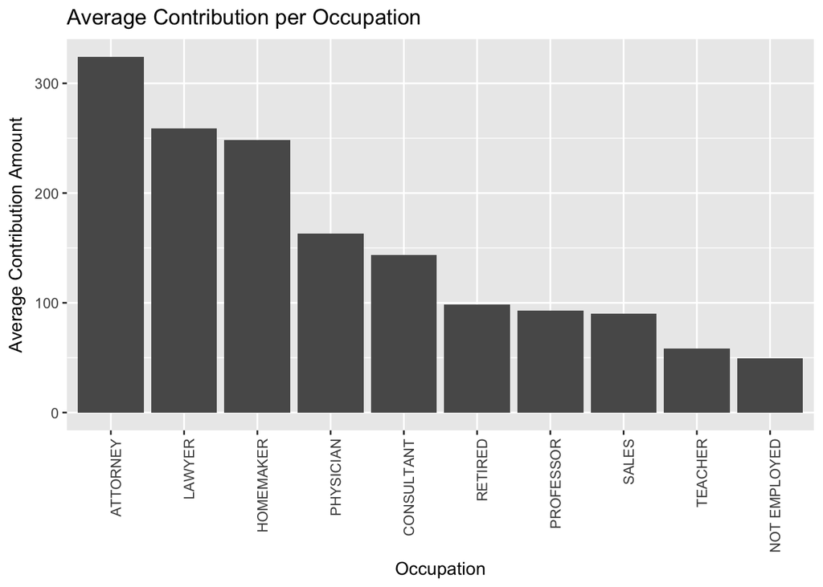

### Description Two

As discussed above, retired and non-employed people are more involved in the presidential campaign. However, from an average contribution perspective, attorney has the highest average contribution, following by lawyer and homemaker, whose average contribution is almost the same. Non-employed people have the lowest average contribution.

### Plot Three

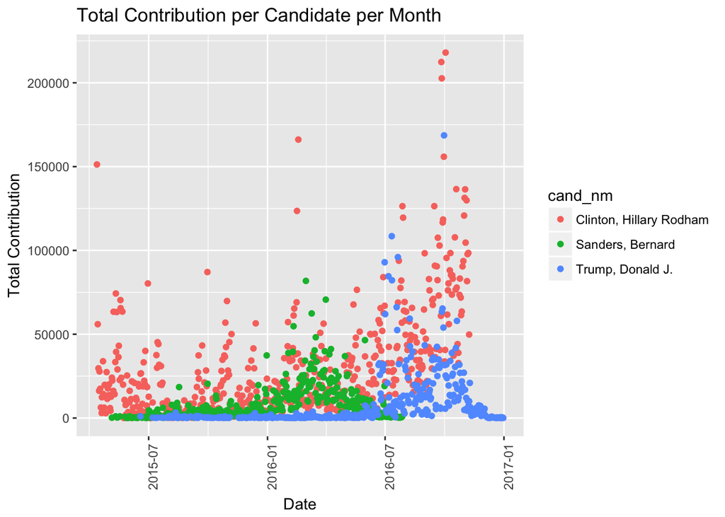

### Description Three

We can see, from this plot, that Hiliary Clinton leads the total contribution  
amount. Bernard Sanders has more contribution from 2015 to 2016. Donald Trump  
has few contributions at the beginning, but starts to get more since 2016.

# Reflection

## Challenages & Struggles

- I actually had some issues reading the dataset at the beginning. I used  
  `read.csv()` at first, but it keeps generating errors. I used  
  `row.names = NULL`, but it generated a row named `NULL` and messed up with  
  the rest of the dataframe. After some research, I used `read_csv()`, which  
  doesn’t have any issues. I will use `read_csv()` going forward.
- I have some struggles with time seires variables in R. In the original  
  dataset, the date information was treaed as characters instead of Date type.  
  It took me a while to clean it up to draw the time seris plot.

## Future Work

This dataset only contains information from Illinois, which is known as the  
state supports Democracy. I am interesting to explore and analyze the campaign  
information in other state as well, which could be a total different story.